# DAPR3 Group Report 2025-26

30% of final course grade

Your task is to describe and analyse some data in order to provide answers to a set of research questions. Analyses will draw on the methodologies we have discussed in lectures, readings and lab exercises.

**Stop!** Before you do anything else, make sure that every member of the group has a record of everyone else’s **exam numbers**, which can be found on their matriculation cards ([see here for more information](https://buddy.vet.ed.ac.uk/help/how-to-find-your-exam-number/)). Whoever submits the coursework on behalf of the group will need to provide these numbers at submission time.

# Group work policy

**Please note that each group should submit a *single* report (two documents: see what-you-need-to-submit). All group members are expected to contribute to the report, but you should not work with other groups.**

Similarity checks will be performed, and further investigations will be carried out if assignments from different groups are similar.

# Use of AI

For group work, the other members of your group are a better resource than any LLM!!

- Using AI in non-assessed work = ✅
  - e.g., LLMs are sometimes helpful for understanding R documentation.
  - But be aware of the environmental cost (https://www.bbc.co.uk/sounds/play/w3ct6vz4)
- using AI in assessed work = ❌
  - Do not use LLMs at all in your assessments, including:
    - planning, conducting, or interpreting analyses
    - structuring or formatting a report
    - generating text or code

Just like plagiarising from human-written texts, presenting AI work as your own is academic misconduct. Engaging with every step of the process yourself is what will help you learn. And learning is why we are all here.

# What you need to submit

Each group is required to submit 2 documents.

1. A final compiled report (**.pdf** format), detailing your analyses, results, interpretation and conclusions.
   - **No longer than 4 pages**, excluding *optional* 4 page appendix (see below)
   - Doesn’t contain visible R code – aim to write something like the “analysis and results” section of a published paper, which describes, reports, presents and interprets statistical analyses (more detail in the rubric).
2. The **.Rmd** or **.R** document which reproduces the results you give in the report.

# Page limit

**Your report should be no longer than 4 pages in PDF format**.

*If you are knitting to html, please open the html in a browser and print to pdf in order to check how many pages your submission takes up).*

An **OPTIONAL** Appendix of **maximum four pages**[^1] can be used to present *additional* tables and figures, if you wish (but there is no requirement to do this).

The appendix is a good place for *supplementary* materials. By this we mean figures and tables that are not strictly necessary for the reader to understand and replicate your results, but something that an interested researcher might look at if they want *additional* context for your report.

- good use of the appendix:  
  *“The model met the assumptions of linear regression with residuals showing a constant mean of approximately zero across the fitted values (see appendix Fig X), and …”*
- not so good use of the appendix, because important information is left out of the main text:  
  *“The model met assumptions (see appendix Fig X).”*

# Report Formatting

Given what we’ve learned in DAPR1 and 2, we expect most groups to do their analyses using RMarkdown. Hopefully you are aware of the benefits this has for reproducibility.  
However, you are welcome to write the report in a separate word-processor in order to format the report easily without having to remember the nuances of formatting in RMarkdown. This has the additional benefit of being able to use a collaborative word-processor such as Google Docs.

Unfortunately there are no straightforward ways to live edit **.Rmd**/**.R** documents collaboratively; we suggest that each group ensures it knows who holds the “master copy” of the script that will be submitted.

You should then export your word-processor document to **.pdf** format for submission. The code should remain as a file with a **.Rmd** or **.R** suffix.

We don’t mind which of these approaches each group takes: **The important thing to remember is that the data analysis (cleaning, models, and plots) that are presented in the report should match those produced by your code.**

**If you *do* want to format in RMarkdown**

If you *do* wish to do some or all of your formatting in RMarkdown, then we suggest the following readings for help:

- [UoEPsy Rmd-Bootcamp](https://uoepsy.github.io/scs/rmd-bootcamp)
- [RMarkdown CheatSheet](https://rstudio.com/wp-content/uploads/2015/02/rmarkdown-cheatsheet.pdf)
- [Writing Math in Rmd](https://rpruim.github.io/s341/S19/from-class/MathinRmd.html#:~:text=Math%20inside%20RMarkdown,10n%3D1n2.)

Feel free also to post formatting questions on the Piazza discussion forum.

**A note on knitting .Rmd directly to pdf**

Getting RMarkdown to knit directly to pdf can be a pain, and formatting is difficult.

We recommend:

- knit to **.html**, then Ctrl+P to print to **.pdf**
- knit to **.docx**, then export to **.pdf**

# Submitting your files

### Pre-submission checks

Before submitting, we **strongly advise** you to check that your group’s code runs. The easiest way to check this is to:

- Clear your environment, restart your R session (top menu, Session > Restart R), and run your code line by line to see if any errors arise.

### Filenames

For both files which you submit, the filename should be your group name with the appropriate extension, and nothing else.  
For example, the group named **Canary** would submit two files:

1. either **Canary.R** or **Canary.Rmd**, AND
2. **Canary.pdf**

**Working individually?**

For anyone who has obtained permission to complete the assessment individually, please name each file with your exam number (the letter “B” followed by a six digit number – which can be found on your student card: [See here for more information](https://buddy.vet.ed.ac.uk/help/how-to-find-your-exam-number/)). For example, if your exam number was B123456 you would submit:

1. either **B123456.R** or **B123456.Rmd**, AND
2. **B123456.pdf**

You should also write your exam number in the “Submission Title” box prior to submission.

### Where to submit

**ONLY ONE PERSON FROM EACH GROUP NEEDS TO SUBMIT**

We suggest that you do this together/on a call, so that all group members are able to confirm that they are happy to submit.

Go to the Assessments page on Learn, and look for “Assessment Submission”. There you will find two submission boxes where you can submit.

For **each file** you should complete the “Submit File” popup by entering the exam numbers of *all of your group members* in the “Submission Title” box (see below).

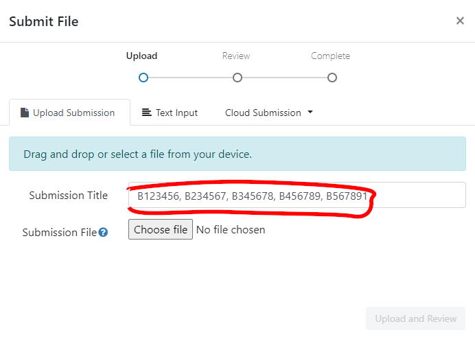

### Late penalties

Submissions are considered late until **both** files are submitted on Turnitin ([see the PPLS policy on late penalties on the UG Hub](https://uoe.sharepoint.com/sites/hss/ppls/PPLS-Undergraduate-Student-Hub-home/SitePages/Submission-process-and-policy.aspx)).

# Grading

**We are primarily marking each group’s *report*, and *not* your code.**

Grades and feedback are provided for the finished reports, with marks awarded for providing evidence of the ability to:

- understand and execute appropriate statistical methods to answer each of the questions.
- provide clear explanation of the methods undertaken.
- provide clear and accurate presentation and interpretation of results and conclusions.

**Why we still want your code**  
We still require your code so that we can assess the reproducibility of your work. We also use it as a way to give you extra marks based on the elegance of your coding and/or use of RMarkdown.

## Rubric

Grading is based on:

- **Strategy (40%)**
  - Clear and useful description of the sample used in the analyses.
  - Appropriate analyses conducted to address the research aims, building on methods taught in the class.
  - Clear explanation of the analyses undertaken.
  - Transparent and justified explanations of any decisions made about the data prior to and during analyses.
- **Results (40%)**
  - Appropriate presentation of the relevant results, with sufficient information of the inferential conclusions (for instance, a test statistic, standard error, *and* p-value, not just one of these). Remember to cite degrees of freedom where needed.
  - Clear and accurate interpretation (in the form of a written paragraph(s) referencing relevant parts of your results and statistics) leading to a conclusion regarding the question.
  - Use of clearly interpretable plots and tables where appropriate to provide additional presentation of findings.
- **Writing & Formatting (10%)**
  - Clarity of writing and structure, use of appropriate language avoiding unnecessary jargon or overly complex explanations.
- **Code Check (10%)**
  - Ability of the code to precisely reproduce the analyses, results, and plots presented in the report.

**Important (Helpful) Tips:**

- The `.pdf` report should not contain visible R code, meaning that a large part of the challenge comes in clearly describing all aspects of the analysis procedure.
- A reader of your report should be able to more or less replicate your analyses **without** referring to your R code (or using R).
- Write as if the reader has a basic understanding of statistics and does not necessarily use R. Imagine that you’re writing for someone who has the same theoretical knowledge as you but is not in this course.
- You do **not** need to include information about the study background or the collection of the data in your report.

## Peer-adjusted marking

Once the group project has been submitted, every member of the group will complete the peer-assessment, in which you will be asked to award “mark adjustments” to yourself and to each of the other members of your group. This will be done through Learn; details will be made available over the next couple of weeks.

Each submitted mark should be understood as follows: **Relative to the group as a whole, how much did each member contribute?** If someone made an average contribution, you should award that person the middle score. If they contributed substantially more, you may choose to give a higher mark; if they genuinely contributed less, you might choose a lower mark. Marks for each group member are scaled then averaged together, and then used as “weights” to adjust the overall project mark.

You can see an example of how this logic works by visiting https://uoe-psy.shinyapps.io/peer_adj/ where there is a “live demo” of a peer-adjustment system.

If you don’t contribute any peer-adjustment marks, other members’ marks will hold more weight in the adjustments made.

# Any questions?

This document contains a basic overview of the assessment and of how to submit it. If you have any questions concerning the coursework report, we ask that you post them on the designated section of the Piazza discussion forum on Learn. If you have a question, it is likely your classmates may have the same question. Before posting a question, please check the on-line board in case it has already been answered.

# Assignment Details

> Conduct and report on an analysis that addresses the research aims of the study detailed below.  
> Data: https://uoepsy.github.io/data/dapr3_2526_report_data.csv, and a data dictionary can be found in Table 1.

### Study background

Much of human communication is ultimately an attempt to convey information that is inherently subjective. The popular game “Wavelength” provides a compelling context to investigate this phenomenon. You can download an app and play the game at https://www.wavelength.zone/. If you want to see the game in action, you can [watch this YouTube short](https://www.youtube.com/shorts/ZFgvTfVt49I).

The game involves a speaker and a guesser (it can also be played with a team of guessers). The speaker is presented with a dial positioned on a spectrum, which has two contrasting concepts at either end (e.g., “Hot” vs. “Cold”, as in Figure 1). The speaker’s task is to provide a single-word or short-phrase clue that precisely locates the dial’s position along this spectrum. For example, if the dial is positioned near the middle of “Hot” vs. “Cold”, then the speaker might offer the clue “lukewarm”. The guesser, without seeing the dial’s actual position, must then rotate their own dial to the location they believe the clue represents (Figure 2). The goal is for the guesser to align their dial as closely as possible to the speaker’s original position. The accuracy of their guess is measured by how close their final dial position is to the target. This provides a quantifiable measure of the effectiveness of the speaker’s communication in conveying a subjective concept.

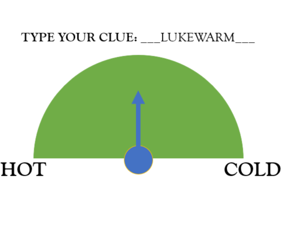

Figure 1: Example speaker’s view – the arrow is fixed, and the speaker’s task is to give a clue that will help the guesser position their own arrow in the right spot

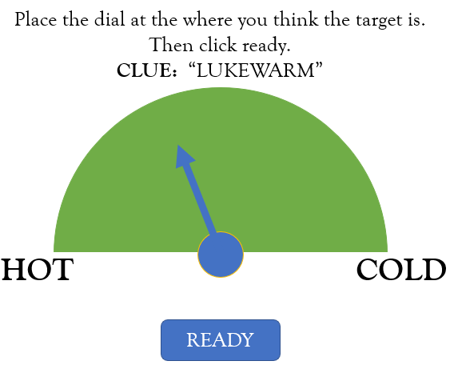

Figure 2: Example guessers’ view – the arrow is free to move, and the guesser positions it based on the given spectrum and the speaker’s clue

24 pairs each played a game of Wavelength that used the same set of 30 spectrums. The spectrums were split into 3 categories, for each of which there were 10 specific spectrums. There were 10 spectrums that could be interpreted as representing measurable quantities (“Cold <–> Hot”, the **quantifiable** category), 10 that captured personal preferences (“Good movie <–> Bad movie”, the **qualitative** category), and 10 that captured social constructs (“Art <–> Not Art”, the **social** category).

In each pair, one person took the role of speaker for the duration of the game, and the other took the role of guesser. The order of the trials was randomised, and the position of the dial for the speaker on each trial was randomly assigned. Scores were constructed as a composite of the accuracy (how far away from the speaker’s prompt dial the guesser’s response was) and the time taken to settle on a response.

### Study aims

The research aims are to investigate if more extreme dial positions are associated with more effective communication (i.e., higher scores), and whether this association is different depending on the category of the spectrum.

**Important information**

“more extreme dial positions” doesn’t discern between direction, so –100 and +100 are the same level of ‘extreme’.

Table 1: Data Dictionary: dapr3_2526_report_data.csv

| variable | description |
| --- | --- |
| pair | ID of pair |
| lengthknown | Length (years) that the pair has known one another for |
| gid | Whether the pair identified as the same genders as one another (0 = no, 1 = yes) |
| dial | Speaker's dial position for a given trial (range –100 to 100, with 0 representing the mid-point) |
| absdial | Speaker's dial position for a given trial (absolute value, scaled by a factor of 1/10) |
| spectrum | Spectrum provided for the trial (e.g., hot vs cold) |
| category | Category of spectrum (quantifiable, qualitative, and social) |
| score | Score obtained on the trial. Scores range from 0 to 100, with higher scores indicating more accurate and more timely guesses. |

## Footnotes

[^1]: meaning that your final `.pdf` file should be max 8 pages.